# ISA 491A Homework 3 Jacob Igel

```r
pacman::p_load(DataExplorer, tidyverse, corrr)
```

### Part 1: PCA Practice

1. Read in the “wine.csv” data set. You should have 178 rows of 14 variables. Everything should be coded correctly without any adjustments. You should have 1 factor and the rest numeric or integer. We are going to perform a PCA on this data so first we need to subset the numeric variables. Use the code below to make an index of “nums” that contains the column numbers of numeric or integer variables.

```r
df <- read.csv("wine.csv", stringsAsFactors = TRUE)

nums <- unlist(lapply(df, is.numeric))
nums
```

```
##                 Type              Alcohol           Malic_Acid
##                FALSE                 TRUE                 TRUE
##                  Ash       Ash_Alcalinity            Magnesium
##                 TRUE                 TRUE                 TRUE
##        Total_Phenols           Flavanoids Nonflavanoid_Phenols
##                 TRUE                 TRUE                 TRUE
##      Proanthocyanins      Color_Intensity                  Hue
##                 TRUE                 TRUE                 TRUE
##          OD280_OD315              Proline
##                 TRUE                 TRUE
```

Then subset the data so it just includes those **columns**. Show the `str()` output.

```r
nums <- df[c(-1)]
str(nums)
```

```
## 'data.frame':    178 obs. of  13 variables:
##  $ Alcohol             : num  14.2 13.2 13.2 14.4 13.2 ...
##  $ Malic_Acid          : num  1.71 1.78 2.36 1.95 2.59 1.76 1.87 2.15 1.64 1.35 ...
##  $ Ash                 : num  2.43 2.14 2.67 2.5 2.87 2.45 2.45 2.61 2.17 2.27 ...
##  $ Ash_Alcalinity      : num  15.6 11.2 18.6 16.8 21 15.2 14.6 17.6 14 16 ...
##  $ Magnesium           : int  127 100 101 113 118 112 96 121 97 98 ...
##  $ Total_Phenols       : num  2.8 2.65 2.8 3.85 2.8 3.27 2.5 2.6 2.8 2.98 ...
##  $ Flavanoids          : num  3.06 2.76 3.24 3.49 2.69 3.39 2.52 2.51 2.98 3.15 ...
##  $ Nonflavanoid_Phenols: num  0.28 0.26 0.3 0.24 0.39 0.34 0.3 0.31 0.29 0.22 ...
##  $ Proanthocyanins     : num  2.29 1.28 2.81 2.18 1.82 1.97 1.98 1.25 1.98 1.85 ...
##  $ Color_Intensity     : num  5.64 4.38 5.68 7.8 4.32 6.75 5.25 5.05 5.2 7.22 ...
##  $ Hue                 : num  1.04 1.05 1.03 0.86 1.04 1.05 1.02 1.06 1.08 1.01 ...
##  $ OD280_OD315         : num  3.92 3.4 3.17 3.45 2.93 2.85 3.58 3.58 2.85 3.55 ...
##  $ Proline             : int  1065 1050 1185 1480 735 1450 1290 1295 1045 1045 ...
```

2. Summarize the data containing only the numeric variables that you created in number (1). Are there any missing observations?

From what I can observe, there are no missing observations in the nums data set.

```r
source("/Users/jacobigel/Desktop/School/ISA 491/data summary.R")
summary(nums)
```

```
##     Alcohol        Malic_Acid         Ash        Ash_Alcalinity
##  Min.   :11.03   Min.   :0.740   Min.   :1.360   Min.   :10.60
##  1st Qu.:12.36   1st Qu.:1.603   1st Qu.:2.210   1st Qu.:17.20
##  Median :13.05   Median :1.865   Median :2.360   Median :19.50
##  Mean   :13.00   Mean   :2.336   Mean   :2.367   Mean   :19.49
##  3rd Qu.:13.68   3rd Qu.:3.083   3rd Qu.:2.558   3rd Qu.:21.50
##  Max.   :14.83   Max.   :5.800   Max.   :3.230   Max.   :30.00
##    Magnesium      Total_Phenols     Flavanoids    Nonflavanoid_Phenols
##  Min.   : 70.00   Min.   :0.980   Min.   :0.340   Min.   :0.1300
##  1st Qu.: 88.00   1st Qu.:1.742   1st Qu.:1.205   1st Qu.:0.2700
##  Median : 98.00   Median :2.355   Median :2.135   Median :0.3400
##  Mean   : 99.74   Mean   :2.295   Mean   :2.029   Mean   :0.3619
##  3rd Qu.:107.00   3rd Qu.:2.800   3rd Qu.:2.875   3rd Qu.:0.4375
##  Max.   :162.00   Max.   :3.880   Max.   :5.080   Max.   :0.6600
##  Proanthocyanins Color_Intensity       Hue          OD280_OD315
##  Min.   :0.410   Min.   : 1.280   Min.   :0.4800   Min.   :1.270
##  1st Qu.:1.250   1st Qu.: 3.220   1st Qu.:0.7825   1st Qu.:1.938
##  Median :1.555   Median : 4.690   Median :0.9650   Median :2.780
##  Mean   :1.591   Mean   : 5.058   Mean   :0.9574   Mean   :2.612
##  3rd Qu.:1.950   3rd Qu.: 6.200   3rd Qu.:1.1200   3rd Qu.:3.170
##  Max.   :3.580   Max.   :13.000   Max.   :1.7100   Max.   :4.000
##     Proline
##  Min.   : 278.0
##  1st Qu.: 500.5
##  Median : 673.5
##  Mean   : 746.9
##  3rd Qu.: 985.0
##  Max.   :1680.0
```

```r
data.summary(nums)
```

```
##                             mean          sd    min     max  median length
## Alcohol               13.0006180   0.8118265  11.03   14.83  13.050    178
## Malic_Acid             2.3363483   1.1171461   0.74    5.80   1.865    178
## Ash                    2.3665169   0.2743440   1.36    3.23   2.360    178
## Ash_Alcalinity        19.4949438   3.3395638  10.60   30.00  19.500    178
## Magnesium             99.7415730  14.2824835  70.00  162.00  98.000    178
## Total_Phenols          2.2951124   0.6258510   0.98    3.88   2.355    178
## Flavanoids             2.0292697   0.9988587   0.34    5.08   2.135    178
## Nonflavanoid_Phenols   0.3618539   0.1244533   0.13    0.66   0.340    178
## Proanthocyanins        1.5908989   0.5723589   0.41    3.58   1.555    178
## Color_Intensity        5.0580899   2.3182859   1.28   13.00   4.690    178
## Hue                    0.9574494   0.2285716   0.48    1.71   0.965    178
## OD280_OD315            2.6116854   0.7099904   1.27    4.00   2.780    178
## Proline              746.8932584 314.9074743 278.00 1680.00 673.500    178
##                      missing
## Alcohol                    0
## Malic_Acid                 0
## Ash                        0
## Ash_Alcalinity             0
## Magnesium                  0
## Total_Phenols              0
## Flavanoids                 0
## Nonflavanoid_Phenols       0
## Proanthocyanins            0
## Color_Intensity            0
## Hue                        0
## OD280_OD315                0
## Proline                    0
## data frame with 0 columns and 0 rows
```

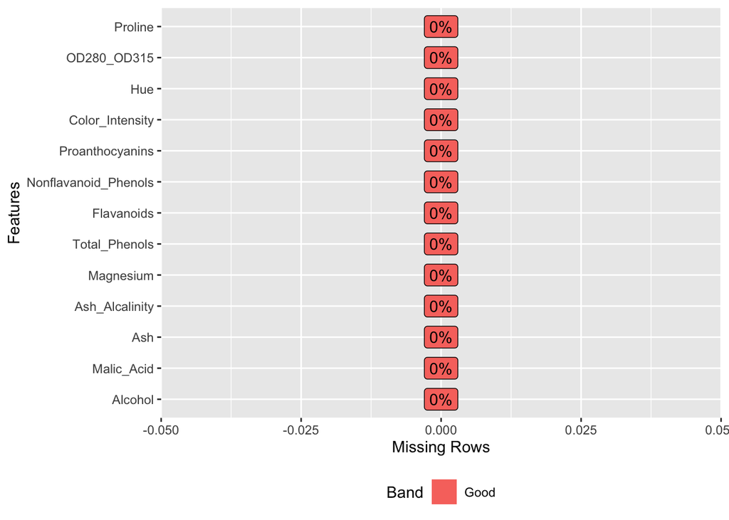

```r
plot_missing(nums)
```

3. Construct a correlation color plot and paste it below. Comment on any strong associations between variables.

One strong postive association is between Flavanoids and Total_phenols. Another strong positive association is between OD280_OD315 and both Flavanoids and Total_phenols.

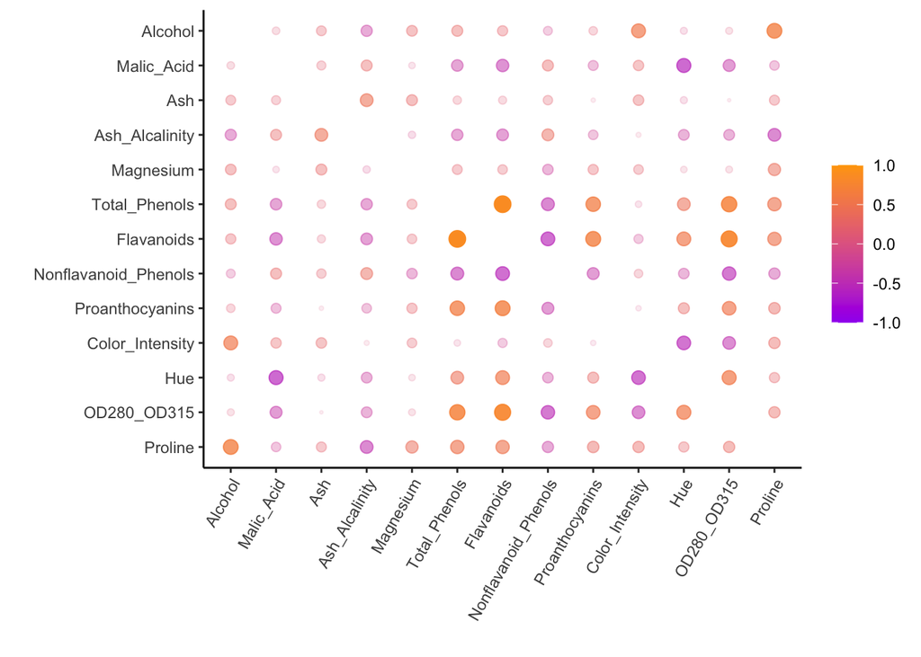

```r
library(corrr)
nums2 <- unlist(lapply(nums, is.numeric))
M <- correlate(nums[,nums2])
rplot(M, print_cor = FALSE, shape = 20, colors=c("purple", "orange"))+
  theme(axis.text.x = element_text(angle = 60, hjust = 1))
```

4. Perform a PCA on all of the numeric variables in the wine data (hopefully the subset you created in number 1). Paste the summary of the PCA below. Be sure to scale the data.

```r
pcs<-prcomp(data.frame(nums), scale = T)
summary(pcs)
```

```
## Importance of components:
##                          PC1    PC2    PC3     PC4     PC5     PC6     PC7
## Standard deviation     2.169 1.5802 1.2025 0.95863 0.92370 0.80103 0.74231
## Proportion of Variance 0.362 0.1921 0.1112 0.07069 0.06563 0.04936 0.04239
## Cumulative Proportion  0.362 0.5541 0.6653 0.73599 0.80162 0.85098 0.89337
##                            PC8     PC9   PC10    PC11    PC12    PC13
## Standard deviation     0.59034 0.53748 0.5009 0.47517 0.41082 0.32152
## Proportion of Variance 0.02681 0.02222 0.0193 0.01737 0.01298 0.00795
## Cumulative Proportion  0.92018 0.94240 0.9617 0.97907 0.99205 1.00000
```

5. How many components are required to maintain at least 99% of the total variation in the data?

12 Principal Components

6. Paste the weights for the first principle component below.

```r
(pcs$rotation[,1])
```

```
##              Alcohol           Malic_Acid                  Ash
##         -0.144329395          0.245187580          0.002051061
##       Ash_Alcalinity            Magnesium        Total_Phenols
##          0.239320405         -0.141992042         -0.394660845
##           Flavanoids Nonflavanoid_Phenols      Proanthocyanins
##         -0.422934297          0.298533103         -0.313429488
##      Color_Intensity                  Hue          OD280_OD315
##          0.088616705         -0.296714564         -0.376167411
##              Proline
##         -0.286752227
```

7. Paste the first 6 values of the first PC below.

```r
head((pcs$rotation[,1]))
```

```
##        Alcohol     Malic_Acid            Ash Ash_Alcalinity      Magnesium
##   -0.144329395    0.245187580    0.002051061    0.239320405   -0.141992042
##  Total_Phenols
##   -0.394660845
```

8. Scale the numeric wine data using `scale(data)`. Paste the first 6 observations below.

```r
nums.scale <- scale(nums)
head(nums.scale)
```

```
##        Alcohol  Malic_Acid        Ash Ash_Alcalinity  Magnesium Total_Phenols
## [1,] 1.5143408 -0.56066822  0.2313998     -1.1663032 1.90852151     0.8067217
## [2,] 0.2455968 -0.49800856 -0.8256672     -2.4838405 0.01809398     0.5670481
## [3,] 0.1963252  0.02117152  1.1062139     -0.2679823 0.08810981     0.8067217
## [4,] 1.6867914 -0.34583508  0.4865539     -0.8069748 0.92829983     2.4844372
## [5,] 0.2948684  0.22705328  1.8352256      0.4506745 1.27837900     0.8067217
## [6,] 1.4773871 -0.51591132  0.3043010     -1.2860793 0.85828399     1.5576991
##      Flavanoids Nonflavanoid_Phenols Proanthocyanins Color_Intensity        Hue
## [1,]  1.0319081           -0.6577078       1.2214385       0.2510088  0.3611585
## [2,]  0.7315653           -0.8184106      -0.5431887      -0.2924962  0.4049085
## [3,]  1.2121137           -0.4970050       2.1299594       0.2682629  0.3174085
## [4,]  1.4623994           -0.9791134       1.0292513       1.1827317 -0.4263410
## [5,]  0.6614853            0.2261576       0.4002753      -0.3183774  0.3611585
## [6,]  1.3622851           -0.1755994       0.6623487       0.7298108  0.4049085
##      OD280_OD315     Proline
## [1,]   1.8427215  1.01015939
## [2,]   1.1103172  0.96252635
## [3,]   0.7863692  1.39122370
## [4,]   1.1807407  2.32800680
## [5,]   0.4483365 -0.03776747
## [6,]   0.3356589  2.23274072
```

```r
mean(scale(nums$Alcohol))
```

```
## [1] -8.591766e-16
```

9. What is the mean of the scaled Alcohol column?

mean(scale(nums$Alcohol)) -8.591766e-16

10. Verify the value of PC1 for the second observation. You can do this calculation in R and show it below.

```r
pcs$rotation
```

```
##                               PC1          PC2         PC3         PC4
## Alcohol              -0.144329395  0.483651548 -0.20738262  0.01785630
## Malic_Acid            0.245187580  0.224930935  0.08901289 -0.53689028
## Ash                   0.002051061  0.316068814  0.62622390  0.21417556
## Ash_Alcalinity        0.239320405 -0.010590502  0.61208035 -0.06085941
## Magnesium            -0.141992042  0.299634003  0.13075693  0.35179658
## Total_Phenols        -0.394660845  0.065039512  0.14617896 -0.19806835
## Flavanoids           -0.422934297 -0.003359812  0.15068190 -0.15229479
## Nonflavanoid_Phenols  0.298533103  0.028779488  0.17036816  0.20330102
## Proanthocyanins      -0.313429488  0.039301722  0.14945431 -0.39905653
## Color_Intensity       0.088616705  0.529995672 -0.13730621 -0.06592568
## Hue                  -0.296714564 -0.279235148  0.08522192  0.42777141
## OD280_OD315          -0.376167411 -0.164496193  0.16600459 -0.18412074
## Proline              -0.286752227  0.364902832 -0.12674592  0.23207086
##                              PC5         PC6         PC7         PC8
## Alcohol              -0.26566365  0.21353865 -0.05639636  0.39613926
## Malic_Acid            0.03521363  0.53681385  0.42052391  0.06582674
## Ash                  -0.14302547  0.15447466 -0.14917061 -0.17026002
## Ash_Alcalinity        0.06610294 -0.10082451 -0.28696914  0.42797018
## Magnesium             0.72704851  0.03814394  0.32288330 -0.15636143
## Total_Phenols        -0.14931841 -0.08412230 -0.02792498 -0.40593409
## Flavanoids           -0.10902584 -0.01892002 -0.06068521 -0.18724536
## Nonflavanoid_Phenols -0.50070298 -0.25859401  0.59544729 -0.23328465
## Proanthocyanins       0.13685982 -0.53379539  0.37213935  0.36822675
## Color_Intensity      -0.07643678 -0.41864414 -0.22771214 -0.03379692
## Hue                  -0.17361452  0.10598274  0.23207564  0.43662362
## OD280_OD315          -0.10116099  0.26585107 -0.04476370 -0.07810789
## Proline              -0.15786880  0.11972557  0.07680450  0.12002267
##                              PC9        PC10        PC11        PC12
## Alcohol              -0.50861912  0.21160473  0.22591696 -0.26628645
## Malic_Acid            0.07528304 -0.30907994 -0.07648554  0.12169604
## Ash                   0.30769445 -0.02712539  0.49869142 -0.04962237
## Ash_Alcalinity       -0.20044931  0.05279942 -0.47931378 -0.05574287
## Magnesium            -0.27140257  0.06787022 -0.07128891  0.06222011
## Total_Phenols        -0.28603452 -0.32013135 -0.30434119 -0.30388245
## Flavanoids           -0.04957849 -0.16315051  0.02569409 -0.04289883
## Nonflavanoid_Phenols -0.19550132  0.21553507 -0.11689586  0.04235219
## Proanthocyanins       0.20914487  0.13418390  0.23736257 -0.09555303
## Color_Intensity      -0.05621752 -0.29077518 -0.03183880  0.60422163
## Hue                  -0.08582839 -0.52239889  0.04821201  0.25921400
## OD280_OD315          -0.13722690  0.52370587 -0.04642330  0.60095872
## Proline               0.57578611  0.16211600 -0.53926983 -0.07940162
##                             PC13
## Alcohol               0.01496997
## Malic_Acid            0.02596375
## Ash                  -0.14121803
## Ash_Alcalinity        0.09168285
## Magnesium             0.05677422
## Total_Phenols        -0.46390791
## Flavanoids            0.83225706
## Nonflavanoid_Phenols  0.11403985
## Proanthocyanins      -0.11691707
## Color_Intensity      -0.01199280
## Hue                  -0.08988884
## OD280_OD315          -0.15671813
## Proline               0.01444734
```

```r
head(pcs$x)
```

```
##            PC1        PC2        PC3        PC4        PC5        PC6
## [1,] -3.307421  1.4394023 -0.1652728  0.2150246  0.6910933  0.2232504
## [2,] -2.203250 -0.3324551 -2.0207571  0.2905387 -0.2569299  0.9245123
## [3,] -2.509661  1.0282507  0.9800541 -0.7228632 -0.2503270 -0.5477310
## [4,] -3.746497  2.7486184 -0.1756962 -0.5663856 -0.3109644 -0.1141091
## [5,] -1.006070  0.8673840  2.0209873  0.4086131  0.2976180  0.4053761
## [6,] -3.041674  2.1164309 -0.6276254  0.5141870 -0.6302409 -0.1230834
##              PC7         PC8         PC9        PC10       PC11          PC12
## [1,]  0.59474883 -0.06495586 -0.63963836  1.01808396  0.4502932  0.5392891439
## [2,]  0.05362434 -1.02153432  0.30797798  0.15925214  0.1422560  0.3871456499
## [3,]  0.42301218  0.34324787  1.17452129  0.11304198  0.2858665  0.0005819316
## [4,] -0.38225899 -0.64178311 -0.05239662  0.23873915 -0.7574476 -0.2413387757
## [5,]  0.44282531 -0.41552831 -0.32589984 -0.07814604  0.5244656 -0.2160546934
## [6,]  0.40052393 -0.39378261  0.15171810 -0.10170891 -0.4044444 -0.3783653606
##              PC13
## [1,] -0.066052305
## [2,]  0.003626273
## [3,]  0.021655423
## [4,] -0.368444194
## [5,] -0.079140320
## [6,]  0.144747017
```

```r
head(data.frame(nums))
```

```
##   Alcohol Malic_Acid  Ash Ash_Alcalinity Magnesium Total_Phenols Flavanoids
## 1   14.23       1.71 2.43           15.6       127          2.80       3.06
## 2   13.20       1.78 2.14           11.2       100          2.65       2.76
## 3   13.16       2.36 2.67           18.6       101          2.80       3.24
## 4   14.37       1.95 2.50           16.8       113          3.85       3.49
## 5   13.24       2.59 2.87           21.0       118          2.80       2.69
## 6   14.20       1.76 2.45           15.2       112          3.27       3.39
##   Nonflavanoid_Phenols Proanthocyanins Color_Intensity  Hue OD280_OD315 Proline
## 1                 0.28            2.29            5.64 1.04        3.92    1065
## 2                 0.26            1.28            4.38 1.05        3.40    1050
## 3                 0.30            2.81            5.68 1.03        3.17    1185
## 4                 0.24            2.18            7.80 0.86        3.45    1480
## 5                 0.39            1.82            4.32 1.04        2.93     735
## 6                 0.34            1.97            6.75 1.05        2.85    1450
```

```r
0.245187580 * (1.71 - mean(nums$Malic_Acid)) - 0.002051061 * (2.43 - mean(nums$Ash)) - 0.239320405 * (15.6   - mean(nums$Ash_Alcalinity)) - 0.141992042 * (127 - mean(nums$Magnesium)) - 0.394660845 * (2.80    - mean(nums$Total_Phenols)) - 0.422934297 * (3.06  - mean(nums$Flavanoids)) - 0.298533103 * (0.28    - mean(nums$Nonflavanoid_Phenols)) - 0.313429488 * (2.29 - mean(nums$Proanthocyanins)) - 0.088616705 * (5.64 - mean(nums$Color_Intensity)) - 0.296714564 * (1.04 - mean(nums$Hue)) - 0.376167411 * (3.92 - mean(nums$OD280_OD315))- 0.286752227 * (1065 - mean(nums$Proline))
```

```
## [1] -95.70794
```

### Part 2: Dimension Reduction and Imputation for Lending Club

#### Imputation

11. Read in the `lendingclub.RDS` file. This data has been cleaned using the steps in Homework 2.

```r
lendclub <- readRDS("lendinglclub.RDS")
```

12. In homework 2 we created a few variables one of them was “emp_title_length”. Make a histogram of that variable. Change the bin width to 50.

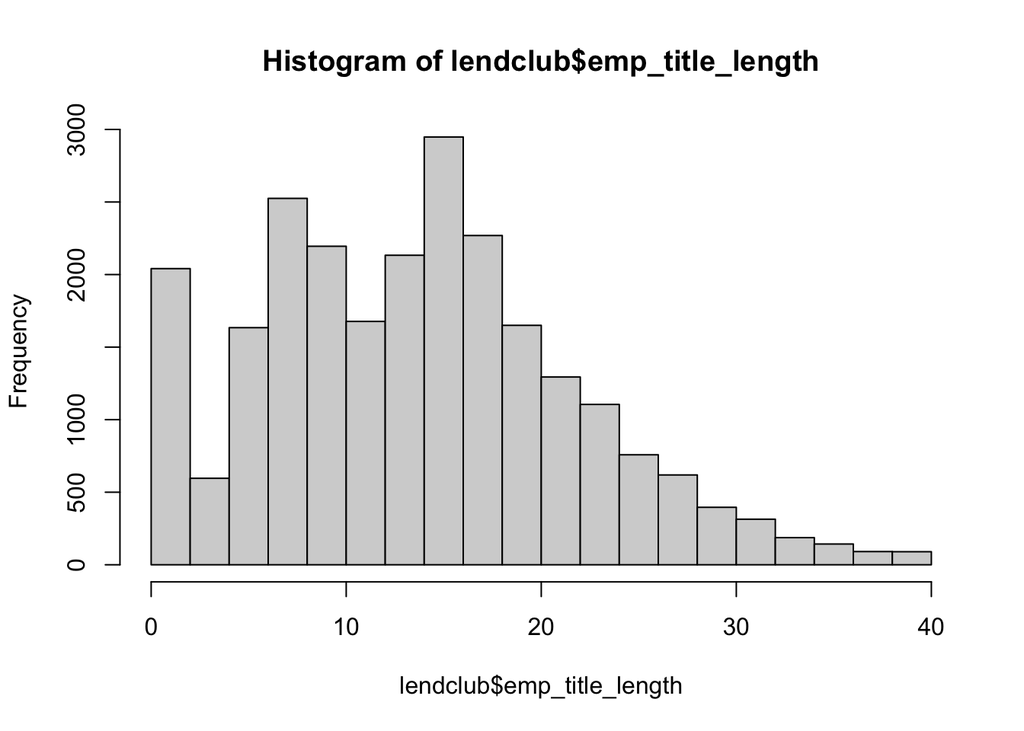

```r
hist(lendclub$emp_title_length, binwidth = 50)
```

13. You should notice there are a lot of 0’s. That is a place where the employment title was left blank. Replace those 0’s with `NA`. Show the summary of that variable below. Should we do this with any 0 values in a variable? Why or why not? Why did we do that here?

Not every variable should be replaced with NA if there are a lot of zeros. Doing this with every variable would cause issues with variables that make sense to have 0 values in them. When doing it with employee title, no one can have a title of 0 characters hense why it makes sense to remove the zeros and replace them with NA values.

```r
lendclub$emp_title_length[lendclub$emp_title_length== 0]<-NA
summary(lendclub$emp_title_length)
```

```
##    Min. 1st Qu.  Median    Mean 3rd Qu.    Max.    NA's
##    2.00    9.00   15.00   15.14   20.00   40.00    1777
```

14. Impute the variables with missing values. Use the median. Only create indicators for those with more than 10% missing. Show your code and a summary to verify there are no missing values after imputation.

The only three with missing rows are below 10%.

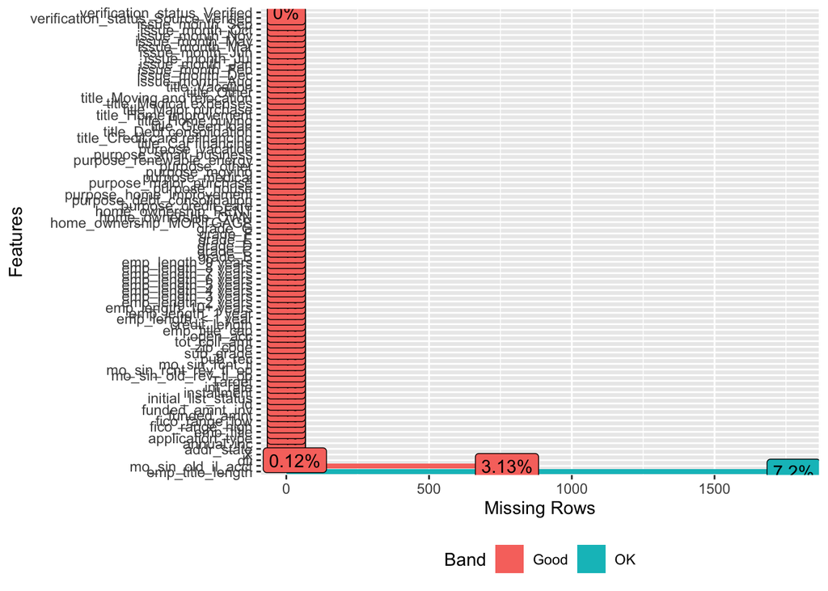

```r
plot_missing(lendclub)
```

```r
lendclub$emp_title_length[is.na(lendclub$emp_title_length)]<-median(lendclub$emp_title_length, na.rm=TRUE)
summary(lendclub$emp_title_length)
```

```
##    Min. 1st Qu.  Median    Mean 3rd Qu.    Max.
##    2.00   10.00   15.00   15.13   19.00   40.00
```

#### Dimension Reduction

15. Use proportions to collapse addr_state. Keep the top 8 states by proportion. Show the code and the dim() of the data. We did not already create dummy varaibles so I would use `ifelse`. Make sure to remove the orginial varaible.

```r
library(tidyverse)

sort(summary(lendclub$addr_state), decreasing=TRUE)
```

```
##   CA   NY   TX   FL   IL   NJ   PA   OH   GA   VA   NC   MD   MI   AZ   MA   CO
## 3304 2086 2045 1762  995  878  842  812  756  652  649  633  605  596  582  566
##   WA   IN   MN   CT   MO   TN   NV   WI   SC   AL   LA   OR   KY   OK   KS   AR
##  491  444  443  432  410  402  382  340  312  292  285  271  257  220  205  186
##   MS   UT   NE   NH   NM   RI   HI   ID   ME   DE   MT   VT   DC   ND   WY   AK
##  149  148  132  132  127  123   89   79   73   70   63   60   59   54   54   52
##   SD   WV
##   45   21
```

```r
lendclub$addr_state<-ifelse(lendclub$addr_state=="CA", 1, 0)
lendclub$addr_state<-ifelse(lendclub$addr_state=="NY", 1, 0)
lendclub$addr_state<-ifelse(lendclub$addr_state=="TX", 1, 0)
lendclub$addr_state<-ifelse(lendclub$addr_state=="FL", 1, 0)
lendclub$addr_state<-ifelse(lendclub$addr_state=="IL", 1, 0)
lendclub$addr_state<-ifelse(lendclub$addr_state=="NJ", 1, 0)
lendclub$addr_state<-ifelse(lendclub$addr_state=="PA", 1, 0)
lendclub$addr_state<-ifelse(lendclub$addr_state=="OH", 1, 0)

dim(lendclub)
```

```
## [1] 24665    82
```

16. Collapse sub_grade using proportion. Create dummy variables for all sub_grades with more than 1000 entries. Show the code below and the final `dim()`. We did not already create dummy variables so I would use `ifelse`. Make sure to remove the original variable.

```r
sort(summary(lendclub$sub_grade), decreasing=TRUE)
```

```
##   C1   B5   C5   C4   B1   C3   C2   B3   B2   B4   A5   A1   A4   D1   A3   D2
## 1785 1772 1645 1624 1567 1563 1476 1467 1379 1199 1137  866  810  810  809  735
##   A2   D3   D4   D5   E2   E5   E1   E3   E4   F1   F3   F2   F5   G1   F4   G4
##  729  729  479  414  268  242  229  192  184  107   73   70   62   59   56   45
##   G5   G2   G3
##   31   27   25
```

```r
lendclub$sub_grade<-ifelse(lendclub$sub_grade=="C1", 1, 0)
lendclub$sub_grade<-ifelse(lendclub$sub_grade=="B5", 1, 0)
lendclub$sub_grade<-ifelse(lendclub$sub_grade=="C5", 1, 0)
lendclub$sub_grade<-ifelse(lendclub$sub_grade=="C4", 1, 0)
lendclub$sub_grade<-ifelse(lendclub$sub_grade=="B1", 1, 0)
lendclub$sub_grade<-ifelse(lendclub$sub_grade=="C3", 1, 0)
lendclub$sub_grade<-ifelse(lendclub$sub_grade=="C2", 1, 0)
lendclub$sub_grade<-ifelse(lendclub$sub_grade=="B3", 1, 0)
lendclub$sub_grade<-ifelse(lendclub$sub_grade=="B2", 1, 0)
lendclub$sub_grade<-ifelse(lendclub$sub_grade=="B4", 1, 0)
lendclub$sub_grade<-ifelse(lendclub$sub_grade=="A5", 1, 0)

dim(lendclub)
```

```
## [1] 24665    82
```

18. Examine the correlation structure of the data. Are there redundancies? If so, state them and what should be done with those variables. You don’t actually have to do those things, just find out if there are redundancies.

It appears that at the lower right hand side and upper left there appear to be some redundancies in the data. With this, I would possibly create some principal components so that we can reduce some of the clutter while maintaining no loss of information.

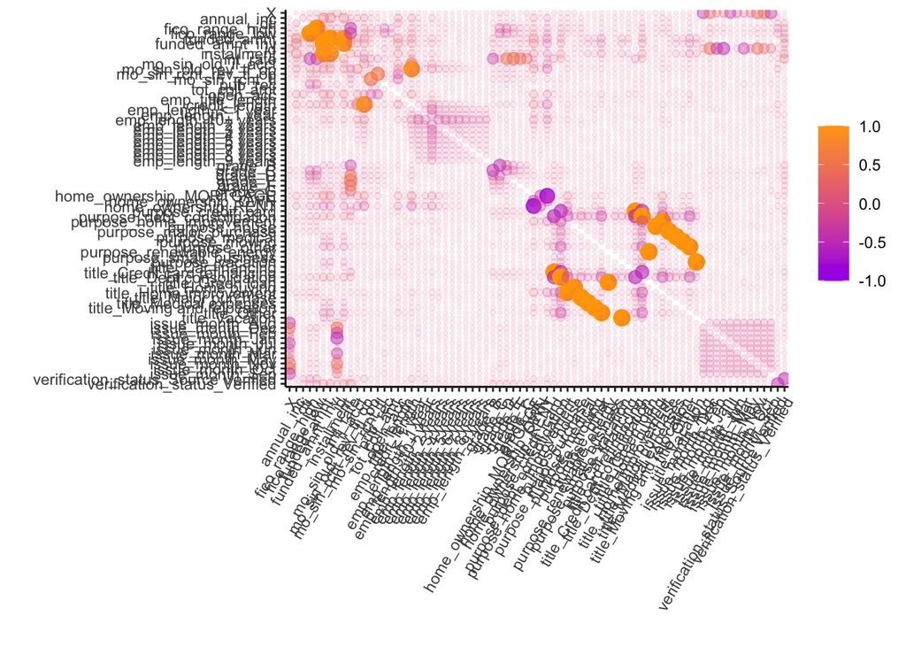

```r
library(corrr)
lendclubnum <- unlist(lapply(lendclub, is.numeric))
M<-correlate(lendclub[,lendclubnum])
rplot(M, print_cor = FALSE, shape = 20, colors=c("purple", "orange"))+
  theme(axis.text.x = element_text(angle = 60, hjust = 1))
```